# Tema 11 - Introducción a distribuciones de probabilidad

## Conceptos básicos

## Experimento aleatorio

Experimento aleatorio. Experimento que efectuado en las mismas condiciones puede dar lugar a resultados diferentes

Suceso elemental. Cada uno de los posibles resultados del experimento aleatorio

Espacio muestral. Conjunto \(\Omega\) formado por todos los sucesos elementales del experimento aleatorio

**Ejemplo**

Lanzar una moneda es un experimento aleatorio

Los sucesos elementales son: sacar cara (\(C\)) y sacar cruz (\(+\))

El espacio muestral de este experimento aleatorio es \(\Omega = \{C,+\}\)

## Sucesos

Suceso. Subconjunto del espacio muestral

Suceso total o seguro. \(\Omega\)

Suceso vacío o imposible. \(\emptyset\)

**Ejemplo**

Lanzar un dado es un experimento aleatorio

Algunos sucesos podrían ser: sacar número par (\(\{2,4,6\}\)), sacar mayor que 4 (\(\{5,6\}\)), sacar número múltiplo de 3 (\(\{3,6\}\))…

El suceso total de este experimento aleatorio es \(\Omega = \{1,2,3,4,5,6\}\)

Un ejemplo de suceso imposible de este experimento aleatorio es \(\emptyset = \{7\}\) (sacar 7)

## Sucesos

Operaciones con sucesos. Sean \(A,B\subseteq \Omega\) sucesos. Entonces,

- \(A\cup B\) es el suceso unión (resultados pertenecen a \(A\), o a \(B\), o a ambos)
- \(A\cap B\) es el suceso intersección (resultados pertenecen a \(A\) y \(B\))
- \(A^c\) es el suceso complementario (resultados que no pertenecen a \(A\))
- \(A-B = A\cap B^c\) es el suceso diferencia (resultados que pertenecen a \(A\) pero no a \(B\))

Sucesos incompatibles. Si \(A\cap B = \emptyset\)

## Probabilidad

Probabilidad de un suceso. Número entre 0 y 1 (ambos incluidos) que mide la expectativa de que se dé este suceso

**Ejemplo**

- La probabilidad de sacar un 6 al lanzar un dado estándar no trucado es \(\frac{1}{6}\)
- La probabilidad de sacar un 6 al lanzar un dado de 4 caras es \(0\)
- La probabilidad de sacar un 6 al lanzar un dado de 20 caras es \(\frac{1}{20}\)

[figure not shown]

## Probabilidad

Probabilidad. Sea \(\Omega\) el espacio muestral de un experimento aleatorio. Suponiendo que \(\Omega\) es **finito**, una probabilidad sobre \(\Omega\) es una aplicación \[p: \mathcal{P}(\Omega)\longrightarrow [0,1]\] que satisface

- \(0\le p(A)\le 1 \ \forall A\in\mathcal{P}(\Omega)\)
- \(p(\Omega) = 1\)
- Si \(\{A_1,\dots,A_n\}\) son sucesos incompatibles dos a dos (\(A_i\cap A_j=\emptyset \ \forall i\ne j\)), entonces \[p(A_1\cup\cdots \cup A_n)=p(A_1)+\cdots+p(A_n)\]

Notación: Si \(a\in\Omega\), escribiremos \(p(a)\) en vez de \(p(\{a\})\)

## Variables aleatorias

## Variable aleatoria

Variable aleatoria. Una variable aleatoria (v.a.) sobre \(\Omega\) es una aplicación \[X: \Omega\longrightarrow \mathbb{R}\] que asigna a cada suceso elemental \(\omega\) un número real \(X(\omega)\)

Puede entenderse como una descripción numérica de los resultados de un experimento aleatorio

Dominio de una variable aleatoria. \(D_X\), es el conjunto de los valores que puede tomar

## Sucesos de variables aleatorias

Una variable aleatoria puede definir sucesos, de los cuales queremos conocer la probabilidad \(p\)

- \(p(X=a) = p(\{\omega\in\Omega \ |\ X(\omega) = a\})\)
- \(p(X<b) = p(\{\omega\in\Omega \ |\ X(\omega) < b\})\)
- \(p(X\le b) = p(\{\omega\in\Omega \ |\ X(\omega) \le b\})\)
- \(p(a<X) = p(\{\omega\in\Omega \ |\ a<X(\omega)\})\)
- \(p(a\le X) = p(\{\omega\in\Omega \ |\ a\le X(\omega)\})\)
- \(p(a\le X\le b) = p(\{\omega\in\Omega \ |\ a\le X(\omega) \le b\})\)
- \(p(a< X< b) = p(\{\omega\in\Omega \ |\ a< X(\omega) < b\})\)
- \(p(X\in A) = p(\{\omega\in\Omega \ |\ X(\omega)\in A\})\)

## Función de distribución

Función de distribución de la v.a. \(X\). Es una función \[F:\mathbb{R}\longrightarrow [0,1]\] definida por \(F(x)=p(X\le x)\)

Sea \(F\) una función de distribución de una v.a. \(X\) y digamos \[F(a^-)=\lim_{x\rightarrow a^-}F(x)\]

- \(p(X\le a)=F(a)\)
- \(p(X<a)=\lim_{b\rightarrow a,\ b<a}p(X\le b) = \lim_{b\rightarrow a,\ b<a} F(b) = F(a^-)\)
- \(p(X=a) = p(X\le a)-p(X<a)=F(a)-F(a^-)\)
- \(p(a\le X\le b) = p(X\le b)-p(X< a)=F(b)-F(a^-)\)

## Cuantiles

Cuantil de orden \(p\) de una v.a. \(X\). Es el \(x_p\in\mathbb{R}\) más pequeño tal que \(F(x_p)\ge p\)

Nótese que la mediana es el cuantil de orden 0.5

## Variables aleatorias discretas

## Variable aleatoria discreta

Variable aleatoria discreta. Una v.a. \(X:\Omega\longrightarrow \mathbb{R}\) es discreta cuando \(D_X\) es finito o un subconjunto de \(\mathbb{N}\)

Función de probabilidad. Es la función \(f:\mathbb{R}\longrightarrow[0,1]\) definida por \[f(x) = p(X=x)\]

Nótese que \(f(x)=0\) si \(x\not\in D_X\). Por tanto, interpretaremos la función de probabilidad como la función \[f:D_X\longrightarrow [0,1]\]

## Esperanza

Esperanza de una v.a. discreta. Sea \(f:D_X\longrightarrow[0,1]\) la función de probabilidad de \(X\), entonces la esperanza respecto de la función de probabilidad es la suma ponderada de los elementos de \(D_X\), multiplicando cada elemento \(x\) de \(D_X\) por su probabilidad, \[E(X) = \sum_{x\in D_X}x\cdot f(x)\]

Si \(g:D_X\longrightarrow \mathbb{R}\) es una aplicación \[E(g(X))=\sum_{x\in D_X}g(x)\cdot f(x)\]

## Varianza

Varianza de una v.a. discreta. Sea \(f:D_X\longrightarrow[0,1]\) la función de probabilidad de \(X\), entonces la varianza respecto de la función de probabilidad es el valor esperado de la diferencia al cuadrado entre \(X\) y su valor medio \(E(X)\), \[Var(X)= E((X-E(X))^2) \]

La varianza mide como de variados son los resultados de \(X\) respecto de la media

**Ejercicio.** Demostrar la siguiente igualdad. \[Var(X)= E(X^2)-(E(X))^2\]

## Varianza

Si \(X\) es una v.a. discreta y \(g:D_X\longrightarrow \mathbb{R}\) una función, \[Var(g(X))=E((g(X)-E(g(X)))^2)=E(g(X)^2)-(E(g(X)))^2\]

## Desviación típica

Desviación típica de una v.a. discreta. Sea \(f:D_X\longrightarrow[0,1]\) la función de probabilidad de \(X\), entonces la desviación típica respecto de la función de probabilidad es \[\sigma(X)=\sqrt{Var(X)}\]

Las unidades de la varianza son las de \(X\) al cuadrado. En cambio, las de la desviación típica son las mismas unidades que las de \(X\)

Si \(X\) es una v.a. discreta y \(g:D_X\longrightarrow \mathbb{R}\) una función, \[\sigma(g(X))=\sqrt{Var(g(X))}\]

## Distribuciones de probabilidad

## Distribución de probabilidad

[Distribución de probabilidad](https://es.wikipedia.org/wiki/Distribución_de_probabilidad). En teoría de la probabilidad y estadística, la distribución de probabilidad de una variable aleatoria es una función que asigna a cada suceso definido sobre la variable la probabilidad de que dicho suceso ocurra.

## Distribuciones en `R`

Dada cualquier variable aleatoria, `va`, `R` nos da cuatro funciones para poder trabajar con ellas:

- `dva(x,...)`: Función de densidad o de probabilidad \(f(x)\) de la variable aleatoria para el valor \(x\) del dominio de definición.
- `pva(x,...)`: Función de distribución \(F(x)\) de la variable aleatoria para el valor \(x\) del dominio de definición.
- `qva(p,...)`: Cuantil \(p\)-ésimo de la variable aleatoria (el valor de \(x\) más pequeño tal que \(F(x)\geq p\)).
- `rva(n,...)`: Generador de \(n\) observaciones siguiendo la distribución de la variable aleatoria.

## Distribuciones en `Python`

Dada cualquier variable aleatoria, en `Python` tenemos las mismas cuatro funciones, sin que su nombre dependa de la misma:

- `pmf(k,...)` o `pdf(x,...)`: Función de probabilidad \(f(k)\) o de densidad \(f(x)\) de la variable aleatoria para los valores \(k\) o \(x\) del dominio.
- `cdf(x,...)`: Función de distribución \(F(x)\) de la variable aleatoria para el valor \(k\) del dominio.
- `ppf(p,...)`: Cuantil \(p\)-ésimo de la variable aleatoria (el valor de \(x\) más pequeño tal que \(F(x)\geq p\)).
- `rvs(size,...)`: Generador de \(size\) observaciones siguiendo la distribución de la variable aleatoria.

También vale la pena conocer la función `stats(moments='mvsk')` que nos devuelve cuatro valores con los estadísticos de la media `m`, la varianza `v`, el sesgo `s` y la curtosis `k` de la distribución.

## Distribuciones discretas más conocidas

## Distribuciones discretas

- Bernoulli
- [Binomial](https://es.wikipedia.org/wiki/Distribución_binomial)
- [Geométrica](https://es.wikipedia.org/wiki/Distribución_geométrica)
- [Hipergeométrica](https://es.wikipedia.org/wiki/Distribución_hipergeométrica)
- Poisson
- [Binomial Negativa](https://es.wikipedia.org/wiki/Distribución_binomial_negativa)

## Distribución de Bernoulli

Si \(X\) es variable aleatoria que mide el “número de éxitos” y se realiza un único experimento con dos posibles resultados (éxito, que toma valor 1, o fracaso, que toma valor 0), diremos que \(X\) se distribuye como una Bernoulli con parámetro \(p\)

\[X\sim \text{Be}(p)\]

donde \(p\) es la probabilidad de éxito y \(q = 1-p\) es la probabilidad de fracaso.

- El **dominio** de \(X\) será \(D_X = \{0,1\}\)
- La **función de probabilidad** vendrá dada por \[f(k) = p^k(1-p)^{1-k} = \left\{ \begin{array}{rl} p & \text{si } k=1 \\ 1-p & \text{si } k=0 \\ 0 & \text{en cualquier otro caso} \end{array} \right.\]

## Distribución de Bernoulli

- La **función de distribución** vendrá dada por \[F(x) = \left\{ \begin{array}{rl} 0 & \text{si } x<0 \\ 1-p & \text{si } 0\le x<1 \\ 1 & \text{si } x\ge 1 \end{array} \right.\]
- **Esperanza** \(E(X) = p\)
- **Varianza** \(Var(X) = pq\)

## Distribución de Bernoulli

El código de la distribución de Beroulli:

- En `R` tenemos las funciones del paquete `Rlab`: `dbern(x,prob), pbern(q,prob), qbern(p,prob), rbern(n, prob)` donde `prob` es la probabilidad de éxito.
- En `Python` tenemos las funciones del paquete `scipy.stats.bernoulli`: `pmf(k,p), cdf(k,p), ppf(q,p), rvs(p, size)` donde `p` es la probabilidad de éxito.

## Distribución Binomial

Si \(X\) es variable aleatoria que mide el “número de éxitos” y se realizan \(n\) ensayos de Bernoulli independientes entre sí, diremos que \(X\) se distribuye como una Binomial con parámetros \(n\) y \(p\)

\[X\sim \text{B}(n,p)\]

donde \(p\) es la probabilidad de éxito y \(q = 1-p\) es la probabilidad de fracaso

- El **dominio** de \(X\) será \(D_X = \{0,1,2,\dots,n\}\)
- La **función de probabilidad** vendrá dada por \[f(k) = {n\choose k}p^k(1-p)^{n-k} \]

## Distribución Binomial

- La **función de distribución** vendrá dada por \[F(x) = \left\{ \begin{array}{cl} 0 & \text{si } x<0 \\ \sum_{k=0}^xf(k) & \text{si } 0\le x<n \\ 1 & \text{si } x\ge n \end{array} \right.\]
- **Esperanza** \(E(X) = np\)
- **Varianza** \(Var(X) = npq\)

Atención. Fijaos que la distribución de Bernoulli es un caso particular de la Binomial. Basta tomar \(n=1\) y tendremos que \(X\sim \text{Be}(p)\) y \(X\sim\text{B}(1,p)\) son equivalentes.

## Distribución Binomial

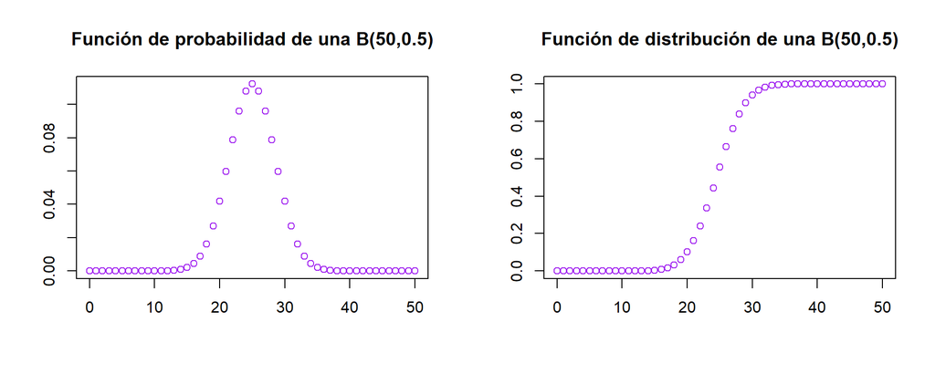

## Distribución Binomial

El código de la distribución Binomial:

- En `R` tenemos las funciones del paquete `Rlab`: `dbinom(x, size, prob), pbinom(q,size, prob), qbinom(p, size, prob), rbinom(n, size, prob)` donde `prob` es la probabilidad de éxito y `size` el número de ensayos del experimento.
- En `Python` tenemos las funciones del paquete `scipy.stats.binom`: `pmf(k,n,p), cdf(k,n,p), ppf(q,n,p), rvs(n, p, size)` donde `p` es la probabilidad de éxito y `n` el número de ensayos del experimento.

## Distribución Geométrica

Si \(X\) es variable aleatoria que mide el “número de repeticiones independientes del experimento hasta haber conseguido éxito”, diremos que \(X\) se distribuye como una Geométrica con parámetro \(p\)

\[X\sim \text{Ge}(p)\] donde \(p\) es la probabilidad de éxito y \(q = 1-p\) es la probabilidad de fracaso

- El **dominio** de \(X\) será \(D_X= \{0,1,2,\dots\}\) o bien \(D_X = \{1,2,\dots\}\) en función de si empieza en 0 o en 1, respectivamente
- La **función de probabilidad** vendrá dada por \[f(k) = (1-p)^{k}p \qquad\text{ si empieza en 0}\] \[f(k) = (1-p)^{k-1}p \qquad\text{ si empieza en 1}\]

## Distribución Geométrica

- La **función de distribución** vendrá dada por \[F(x) = \left\{ \begin{array}{cl} 0 & \text{si } x<0 \\ 1-(1-p)^{k+1} & \text{si } k\le x<k+1,\ k\in\mathbb{N} \end{array} \right.\]
- **Esperanza** \(E(X) = \frac{1-p}{p}\) si empieza en 0 y E\((X) = \frac{1}{p}\) si empieza en 1
- **Varianza** \(Var(X) = \frac{1-p}{p^2}\)
- Propiedad de la falta de memoria. Si \(X\) es una v.a. \(\text{Ge}(p)\), entonces, \[p\{X\ge m+n:\ X\ge n\} = p\{X\ge m\}\ \forall m,n=0,1,\dots\]

## Distribución Geométrica

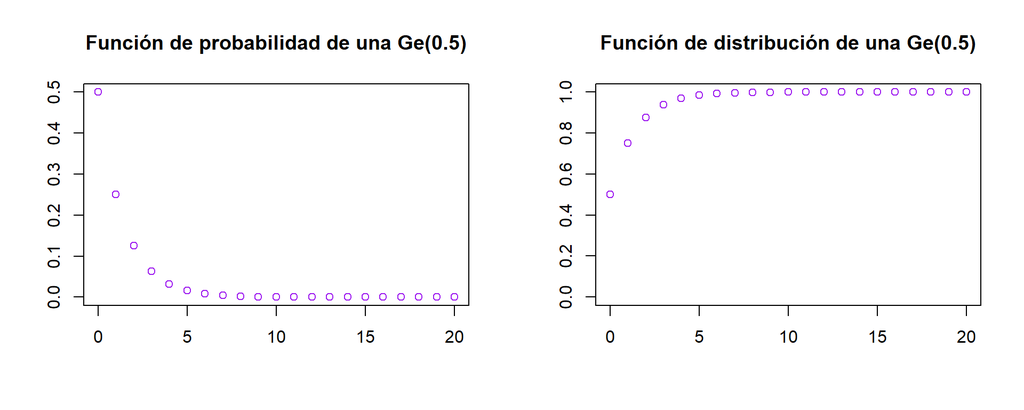

## Distribución Geométrica

El código de la distribución Geométrica:

- En `R` tenemos las funciones del paquete `Rlab`: `dgeom(x, prob), pgeom(q, prob), qgeom(p, prob), rgeom(n, prob)` donde `prob` es la probabilidad de éxito del experimento.
- En `Python` tenemos las funciones del paquete `scipy.stats.geom`: `pmf(k,p), cdf(k,p), ppf(q,p), rvs(p, size)` donde `p` es la probabilidad de éxito del experimento.

## Distribución Hipergeométrica

Consideremos el experimento “extraer a la vez (o una detrás de otra, sin retornarlos) \(n\) objetos donde hay \(N\) de tipo A y \(M\) de tipo B”. Si \(X\) es variable aleatoria que mide el “número de objetos del tipo A”, diremos que \(X\) se distribuye como una Hipergeométrica con parámetros \(N,M,n\) \[X\sim \text{H}(N,M,n)\]

- El **dominio** de \(X\) será \(D_X = \{0,1,2,\dots,N\}\) (en general)
- La **función de probabilidad** vendrá dada por \[f(k) = \frac{{N\choose k}{M\choose n-k}}{N+M\choose n}\]

## Distribución Hipergeométrica

- La **función de distribución** vendrá dada por \[F(x) = \left\{ \begin{array}{cl} 0 & \text{si } x<0 \\ \sum_{k=0}^xf(k) & \text{si } 0\le x<n \\ 1 & \text{si } x\ge n \end{array} \right.\]
- **Esperanza** \(E(X) = \frac{nN}{N+M}\)
- **Varianza** \(Var(X) = \frac{nNM}{(N+M)^2}\cdot\frac{N+M-n}{N+M-1}\)

## Distribución Hipergeométrica

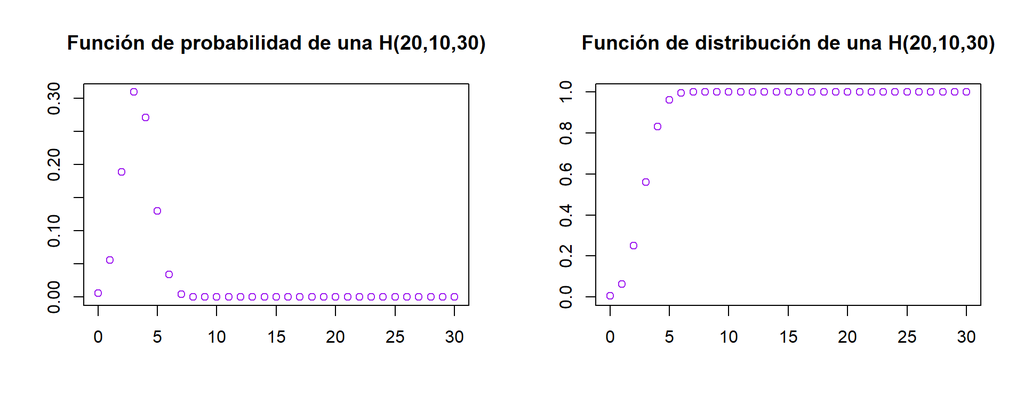

## Distribución Hipergeométrica

El código de la distribución Hipergeométrica:

- En `R` tenemos las funciones del paquete `Rlab`: `dhyper(x, m, n, k), phyper(q, m, n, k), qhyper(p, m, n, k), rhyper(nn, m, n, k)` donde `m` es el número de objetos del primer tipo, `n` el número de objetos del segundo tipo y `k` el número de extracciones realizadas.
- En `Python` tenemos las funciones del paquete `scipy.stats.hypergeom`: `pmf(k,M, n, N), cdf(k,M, n, N), ppf(q,M, n, N), rvs(M, n, N, size)` donde `M` es el número de objetos del primer tipo, `N` el número de objetos del segundo tipo y `n` el número de extracciones realizadas.

## Distribución de Poisson

Si \(X\) es variable aleatoria que mide el “número de eventos en un cierto intervalo de tiempo”, diremos que \(X\) se distribuye como una Poisson con parámetro \(\lambda\)

\[X\sim \text{Po}(\lambda)\] donde \(\lambda\) representa el número de veces que se espera que ocurra el evento durante un intervalo dado

- El **dominio** de \(X\) será \(D_X = \{0,1,2,\dots\}\)
- La **función de probabilidad** vendrá dada por \[f(k) = \frac{e^{-\lambda}\lambda^k}{k!}\]

## Distribución de Poisson

- La **función de distribución** vendrá dada por \[F(x) = \left\{ \begin{array}{cl} 0 & \text{si } x<0 \\ \sum_{k=0}^xf(k) & \text{si } 0\le x<n \\ 1 & \text{si } x\ge n \end{array} \right.\]
- **Esperanza** \(E(X) = \lambda\)
- **Varianza** \(Var(X) = \lambda\)

## Distribución de Poisson

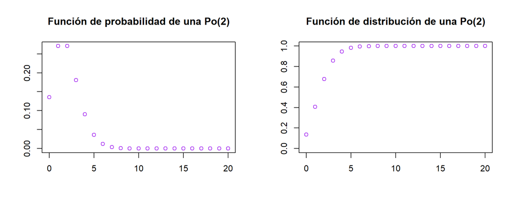

## Distribución de Poisson

El código de la distribución de Poisson:

- En `R` tenemos las funciones del paquete `Rlab`: `dpois(x, lambda), ppois(q,lambda), qpois(p,lambda), rpois(n, lambda)` donde `lambda` es el número esperado de eventos por unidad de tiempo de la distribución.
- En `Python` tenemos las funciones del paquete `scipy.stats.poisson`: `pmf(k,mu), cdf(k,mu), ppf(q,mu), rvs(M,mu)` donde `mu` es el número esperado de eventos por unidad de tiempo de la distribución.

## Distribución Binomial Negativa

Si \(X\) es variable aleatoria que mide el “número de repeticiones hasta observar los \(r\) éxitos en ensayos de Bernoulli”, diremos que \(X\) se distribuye como una Binomial Negativa con parámetros \(r\) y \(p\), \[X\sim\text{BN}(r,p)\] donde \(p\) es la probabilidad de éxito

- El **dominio** de \(X\) será \(D_X = \{r, r+1, r+2,\dots\}\)
- La **función de probabilidad** vendrá dada por \[f(k) = {k-1\choose r-1}p^r(1-p)^{k-r}, k\geq r\]

## Distribución Binomial Negativa

- La **función de distribución** no tiene una expresión analítica.
- **Esperanza** \(E(X) = \frac{r}{p}\)
- **Varianza** \(Var(X) = r\frac{1-p}{p^2}\)

## Distribución Binomial Negativa

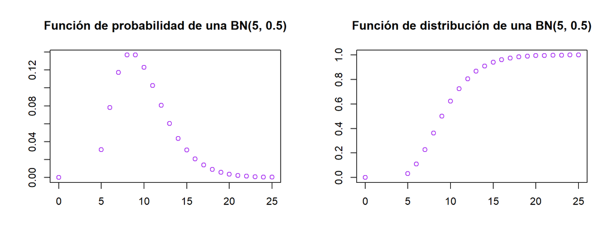

## Distribución Binomial Negativa

El código de la distribución Binomial Negativa:

- En `R` tenemos las funciones del paquete `Rlab`: `dnbinom(x, size, prop), pnbinom(q, size, prop), qnbinom(p, size, prop), rnbinom(n, size, prop)` donde `size` es el número de casos exitosos y `prob` la probabilidad del éxito.
- En `Python` tenemos las funciones del paquete `scipy.stats.nbinom`: `pmf(k,n,p), cdf(k,n,p), ppf(q,n,p), rvs(n,p)` donde `n`es el número de casos exitosos y `p` la probabilidad del éxito.

## Distribuciones discretas en R

R conoce las distribuciones de probabilidad más importantes.

| Distribución | Instrucción en R | Instrucción en Python | Parámetros |
| --- | --- | --- | --- |
| Bernoulli | `bern` | `scipy.stats.bernoulli` | probabilidad de éxito \(p\) |
| Binomial | `binom` | `scipy.stats.binom` | tamaño de la muestra \(n\) y probabilidad de éxito \(p\) |
| Geométrica | `geom` | `scipy.stats.geom` | probabilidad de éxito \(p\) |
| Hipergeométrica | `hyper` | `scipy.stats.hypergeom` | \(N,M,n\) |
| Poisson | `pois` | `scipy.stats.poisson` | esperanza \(\lambda\) |
| Binomial Negativa | `nbinom` | `scipy.stats.nbinom` | número de éxitos \(r\) y probabilidad de éxito \(p\) |

## Variables aleatorias continuas

## Variable aleatoria continua

Variable aleatoria continua. Una v.a. \(X:\Omega\longrightarrow\mathbb{R}\) es continua cuando su función de distribución \(F_X:\mathbb{R}\longrightarrow[0,1]\) es continua

En este caso, \(F_X(x)=F_X(x^-)\) y, por este motivo, \[p(X=x)=0\ \forall x\in\mathbb{R}\] pero esto no significa que sean sucesos imposibles

## Función de densidad

Función de densidad. Función \(f:\mathbb{R}\longrightarrow\mathbb{R}\) que satisface

- \(f(x)\ge 0\ \forall x\in\mathbb{R}\)
- \(\int_{-\infty}^{+\infty}f(t)dt=1\)

Una función de densidad puede tener puntos de discontinuidad

## Variable aleatoria continua

Toda variable aleatoria \(X\) con función de distribución

\[F(x)=\int_{-\infty}^{x}f(t)dt\ \forall x\in\mathbb{R}\] para cualquier densidad \(f\) es una v.a. continua

Diremos entonces que \(f\) es la función de densidad de \(X\)

A partir de ahora, considerareos solamente las v.a. \(X\) continuas que tienen función de densidad

## Esperanza

Esperanza de una v.a. continua. Sea \(X\) v.a. continua con densidad \(f_X\). La esperanza de \(X\) es \[E(X)=\int_{-\infty}^{+\infty}x\cdot f_X(x)dx\]

Si el dominio \(D_X\) de \(X\) es un intervalo de extremos \(a<b\), entonces \[E(X)=\int_a^b x\cdot f_X(x)dx\]

## Esperanza

Sea \(g:D_X\longrightarrow \mathbb{R}\) una función continua. Entonces,

\[E(g(X)) = \int_{-\infty}^{+\infty}g(x)\cdot f_X(x)dx\]

Si el dominio \(D_X\) de \(X\) es un intervalo de extremos \(a<b\), entonces \[E(g(X))=\int_a^b g(x)\cdot f_X(x)dx\]

## Varianza

Varianza de una v.a. continua. Como en el caso discreto, \[Var(X)=E((X-E(X))^2)\]

y se puede demostrar que

\[Var(X)=E(X^2)-(E(X))^2\]

## Desviación típica

Desviación típica de una v.a. continua. Como en el caso discreto, \[\sigma = \sqrt{Var(X)}\]

## Distribuciones continuas más conocidas

## Distribuciones continuas

- [Uniforme](https://es.wikipedia.org/wiki/Distribución_uniforme_continua)
- [Exponencial](https://es.wikipedia.org/wiki/Distribución_exponencial)
- [Normal](https://es.wikipedia.org/wiki/Distribución_normal)
- [Khi cuadrado](https://es.wikipedia.org/wiki/Distribución_χ²)
- [t de Student](https://es.wikipedia.org/wiki/Distribución_t_de_Student)
- [F de Fisher](https://es.wikipedia.org/wiki/Distribución_F)

## Distribución Uniforme

Una v.a. continua \(X\) tiene distribución uniforme sobre el intervalo real \([a,b]\) con \(a<b\), \(X\sim\text{U}(a,b)\) si su función de densidad es \[f_X(x)=\left\{ \begin{array}{rl} \frac{1}{b-a} & \text{si } a\le x\le b \\ 0 & \text{en cualquier otro caso} \end{array} \right.\]

Modela el elegir un elemento del intervalo \([a,b]\) de manera equiprobable

## Distribución Uniforme

- El **dominio** de \(X\) será \(D_X = [a,b]\)
- La **función de distribución** vendrá dada por \[F_X(x)=\left\{ \begin{array}{rl} 0 & \text{si } x<a \\ \frac{x-a}{b-a} & \text{si } a\le x< b \\ 1 & \text{si } x\ge b \end{array} \right.\]
- **Esperanza** \(E(X) = \frac{a+b}{2}\)
- **Varianza** \(Var(X) = \frac{(b-a)^2}{12}\)

## Distribución Uniforme

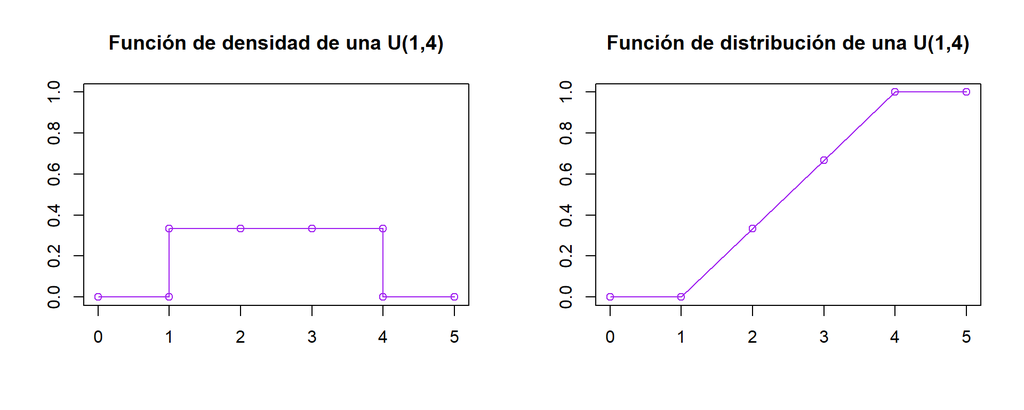

## Distribución Uniforme

El código de la distribución Uniforme:

- En `R` tenemos las funciones del paquete `stats`: `dunif(x, min, max), punif(q, min, max), qunif(p, min, max), runif(n, min, max)` donde `min` y `max` son los extremos de los intervalos de la distribución uniforme.
- En `Python` tenemos las funciones del paquete `scipy.stats.uniform`: `pdf(k,loc, scale), cdf(k,loc, scale), ppf(q,loc, scale), rvs(n,loc, scaler)` donde la distribución uniforme está definida en el intervalo `[loc, loc+scale]`.

## Distribución Exponencial

Una v.a. \(X\) tiene distribución exponencial de parámetro \(\lambda\), \(X\sim\text{Exp}(\lambda)\), si su función de densidad es \[f_X(x)=\left\{ \begin{array}{rl} 0 & \text{si } x\le 0 \\ \lambda\cdot e^{-\lambda x} & \text{si }x>0 \end{array} \right.\]

Teorema. Si tenemos un proceso de Poisson de parámetro \(\lambda\) por unidad de tiempo, el tiempo que pasa entre dos sucesos consecutivos es una v.a. \(\text{Exp}(\lambda)\)

Propiedad de la pérdida de memoria. Si \(X\) es v.a. \(\text{Exp}(\lambda)\), entonces \[p(X>s+t\ :\ X>s)=p(X>t)\ \forall s,t>0\]

## Distribución Exponencial

- El **dominio** de \(X\) será \(D_X = [0,\infty)\)
- La **función de distribución** vendrá dada por \[F_X(x)=\left\{ \begin{array}{rl} 0 & \text{si } x\le 0 \\ 1-e^{-\lambda x} & \text{si } x>0 \end{array} \right.\]
- **Esperanza** \(E(X) = \frac{1}{\lambda}\)
- **Varianza** \(Var(X) = \frac{1}{\lambda^2}\)

## Distribución Exponencial

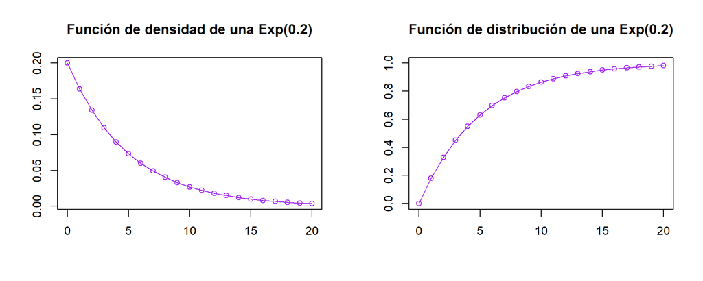

## Distribución Normal

Una v.a. \(X\) tiene distribución normal o gaussiana de parámetros \(\mu\) y \(\sigma\), \(X\sim\mathcal{N}(\mu,\sigma)\) si su función de densidad es \[f_X(x)=\frac{1}{\sqrt{2\pi}\sigma}e^{-\frac{(x-\mu)^2}{2\sigma^2}}\quad \forall x\in\mathbb{R}\]

La gráfica de \(f_X\) es conocida como la Campana de Gauss

Cuando \(\mu = 0\) y \(\sigma = 1\), diremos que la v.a. \(X\) es estándar y la indicaremos usualmente como \(Z\), la cual tendrá función de densidad \[f_Z(z)=\frac{1}{\sqrt{2\pi}}e^{-\frac{z^2}{2}}\quad \forall z\in\mathbb{R}\]

## Distribución Normal

- **Esperanza** \(E(X) = \mu\)
- **Varianza** \(Var(X) = \sigma^2\)

En particular, si \(Z\) sigue una distribución estándar,

- **Esperanza** \(E(X) = 0\)
- **Varianza** \(Var(X) = 1\)

## Distribución Normal

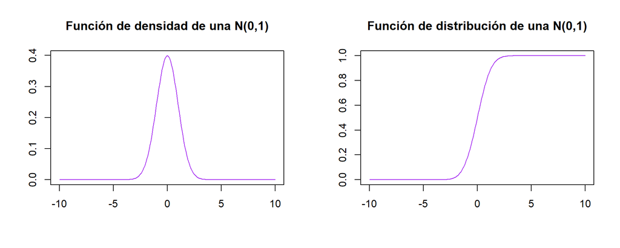

## Distribución Normal

El código de la distribución Normal:

- En `R` tenemos las funciones del paquete `stats`: `dnorm(x, mean, sd), pnorm(q, mean, sd), qnorm(p, mean, sd), rnorm(n, mean, sd)` donde `mean` es la media y `sd` es la desviación estándar de la normal \(N(\mu, \sigma)\).
- En `Python` tenemos las funciones del paquete `scipy.stats.normal`: `pdf(k, mu, scale), cdf(k, mu, scale), ppf(q, mu, scale), rvs(n, mu, scale)` donde `mu` es la media y `scale` es la desviación estándar de la normal \(N(\mu, \sigma)\).

## Distribución Normal

Estandarización de una v.a. normal. Si \(X\) es una v.a. \(\mathcal{N}(\mu,\sigma)\), entonces \[Z=\frac{X-\mu}{\sigma}\sim\mathcal{N}(0,1)\]

Las probabilidades de una normal estándar \(Z\) determinan las de cualquier \(X\) de tipo \(\mathcal{N}(\mu,\sigma)\):

\[p(X\le x)=p\left(\frac{X-\mu}{\sigma}\le\frac{x-\mu}{\sigma}\right)=p\left(Z\le\frac{x-\mu}{\sigma}\right)\]

## Distribución Normal

\(F_Z\) no tiene expresión conocida.

Se puede calcular con cualquier programa, como por ejemplo R, o bien a mano utilizando las [tablas de la \(\mathcal{N}(0,1)\)](https://github.com/joanby/r-basic/blob/master/teoria/TablaNormal.pdf)

Con las tablas se pueden calcular tanto probabilidades como cuantiles

## Distribución Normal en R y Python

Si a la hora de llamar a alguna de las 4 funciones siguientes: `dnorm`, `pnorm`, `qnorm` o `rnorm` no especificásemos los parámetros de la media ni la desviación típica, R entiende que se trata de la normal estándar: la \(\mathcal{N}(0,1)\).

Es decir, R interpreta \(\mu = 0\) y \(\sigma = 1\)

En Python ocurre exactamente lo mismo.

## Otras distribuciones importantes

- La distribución \(\chi^2_k\), donde \(k\) representa los grados de libertad de la misma y que procede de la suma de los cuadrados de \(k\) distribuciones normales estándar independientes:

\[X = Z_1^2 + Z_2^2+\cdots + Z_k^2\sim \chi_k^2\]

## Otras distribuciones importantes

- La distribución \(t_k\) surge del problema de estimar la media de una población normalmente distribuida cuando el tamaño de la muestra es pequeña y procede del cociente

\[T = \frac{Z}{\sqrt{\chi^2_k/k}}\sim T_k\]

## Otras distribuciones importantes

- La distribución \(F_{n_1,n_2}\) aparece frecuentemente como la distribución nula de una prueba estadística, especialmente en el análisis de varianza. Viene definida como el cociente

\[F = \frac{\chi^2_{n_1}/n_1}{\chi^2_{n_2}/n_2}\sim F_{n_1,n_2}\]

## Distribuciones continuas en R

| Distribución | Instrucción en R | Instrucción en Python | Parámetros |
| --- | --- | --- | --- |
| Uniforme | `unif` | `scipy.stats.uniform` | mínimo y máximo |
| Exponencial | `exp` | `scipy.stats.expon` | \(\lambda\) |
| Normal | `norm` | `scipy.stats.normal` | media \(\mu\), desviación típica \(\sigma\) |
| Khi cuadrado | `chisq` | `scipy.stats.chi2` | grados de libertad |
| t de Student | `t` | `scipy.stats.t` | grados de libertad |
| F de Fisher | `f` | `scipy.stats.f` | los dos grados de libertad |

## Otras distribuciones conocidas

- Distribución de Pareto (Power Law)
- Distribución Gamma y Beta
- Distribución Log Normal
- Distribución de Weibull
- Distribución de Cauchy
- Distribución Exponencial Normal
- Distribución Von Mises
- Distribución Rayleigh
- …